# Test

https://github.com/jrkkv5/FIN6572Fall2020/blob/master/National%20Debt/importNationalDebt.Rmd

11/29/2020

```r
library(devtools)
library(blsAPI)
library(rjson)
library(curl)
library(RCurl)
library(knitr)
library(readr)
library(dplyr)
library(tidyverse)
library(rmarkdown)
library(pastecs)
```

```r
library(ggplot2)
library(corrplot)
library(lmtest)
library(forecast)
#loads the necessary packages
```

```r
 merged_final <- read_csv("csv files/mergedFinal.csv")
 #Reads final file into merged dataframe

 merged_final$log_pop = as.numeric(log(merged_final$population))

 merged_final$log_RMHI = as.numeric(log(merged_final$RMHI))
```

As a final step in scrubbing our data, we created new variables to log the population and median household income variables and store it in our dataframe. By taking the logarithmic values, these variables become more comparable to the existing variables we have within our dataset.

Below you can see the table output once all of our data has been merged.

```r
kable(merged_final[1:6,], caption = "Table Including All Variables")
```

Table Including All Variables

| year | period | periodName | value | state | quarter | annual | HPI | MHI | RMHI | poverty | population | sp500 | log_pop | log_RMHI |
| --- | --- | --- | --- | --- | --- | --- | --- | --- | --- | --- | --- | --- | --- | --- |
| 1984 | M12 | December | 9.3 | AK | 4 | 1 | 153.82 | 32356 | 74689 | 9.6 | 513702 | 1.40 | 13.14940 | 11.22109 |
| 1985 | M12 | December | 10.1 | AK | 4 | 1 | 143.07 | 34782 | 77625 | 8.7 | 532495 | 26.33 | 13.18533 | 11.25964 |
| 1986 | M12 | December | 11.0 | AK | 4 | 1 | 138.24 | 31356 | 68775 | 11.4 | 544268 | 14.62 | 13.20720 | 11.13860 |
| 1987 | M12 | December | 9.5 | AK | 4 | 1 | 106.02 | 33233 | 70468 | 12.0 | 539309 | 2.03 | 13.19804 | 11.16291 |
| 1988 | M12 | December | 8.0 | AK | 4 | 1 | 133.16 | 33103 | 67745 | 11.0 | 541983 | 12.40 | 13.20299 | 11.12351 |
| 1989 | M12 | December | 7.1 | AK | 4 | 1 | 102.92 | 36006 | 70599 | 10.5 | 547159 | 27.25 | 13.21249 | 11.16477 |

After our data was merged we binned the states into groups based on the mean population of the years in our dataframe (1984-2018). Below are the bins that were created:

Population < 2,000,000 WV, NM, NE, ID, ME, HI, NH, RI, MT, DE, SD, ND, AK, VT, WY

2,000,000 < Population < 5,000,000 MN, AL, LA, CO, SC, KY, OK, OR, CT, IA, MS, KS, AR, UT, NV

5,000,000 < Population < 10,000,000 MI, NJ, GA, NC, VA, MA, IN, WA, TN, MO, WI, MD, AZ

Population > 10,000,000 CA, TX, NY, FL, PA, IL, OH

Each member of our group performed some basic analysis on the states within one of the bins. After performing our initial analysis we chose to focus on 2 states within each bin. The states we chose to focus on are: TX, IL, MO, WA, OR, CO, WV, ME

Below are some of the highlights along with commentary for the states we have chosen to focus on

```r
IL_data <- merged_final[ merged_final$state == "IL", ]
```

```r
#Descriptive statistics
stat.desc(IL_data)
```

```
##                      year period periodName       value state quarter annual
## nbr.val      3.600000e+01     NA         NA  36.0000000    NA      36     36
## nbr.null     0.000000e+00     NA         NA   0.0000000    NA       0      0
## nbr.na       0.000000e+00     NA         NA   0.0000000    NA       0      0
## min          1.984000e+03     NA         NA   4.1000000    NA       4      1
## max          2.018000e+03     NA         NA  11.0000000    NA       4      1
## range        3.400000e+01     NA         NA   6.9000000    NA       0      0
## sum          7.204500e+04     NA         NA 231.7000000    NA     144     36
## median       2.001500e+03     NA         NA   6.1000000    NA       4      1
## mean         2.001250e+03     NA         NA   6.4361111    NA       4      1
## SE.mean      1.701715e+00     NA         NA   0.3023493    NA       0      0
## CI.mean.0.95 3.454665e+00     NA         NA   0.6138018    NA       0      0
## var          1.042500e+02     NA         NA   3.2909444    NA       0      0
## std.dev      1.021029e+01     NA         NA   1.8140960    NA       0      0
## coef.var     5.101956e-03     NA         NA   0.2818621    NA       0      0
##                      HPI          MHI         RMHI     poverty   population
## nbr.val        36.000000 3.600000e+01 3.600000e+01  36.0000000 3.600000e+01
## nbr.null        0.000000 0.000000e+00 0.000000e+00   0.0000000 0.000000e+00
## nbr.na          0.000000 0.000000e+00 0.000000e+00   0.0000000 0.000000e+00
## min           112.800000 2.375200e+04 5.482800e+04   9.9000000 1.138726e+07
## max           371.210000 7.014500e+04 7.014500e+04  15.6000000 1.289827e+07
## range         258.410000 4.639300e+04 1.531700e+04   5.7000000 1.511012e+06
## sum          9218.510000 1.587843e+06 2.204043e+06 451.4000000 4.422845e+08
## median        276.190000 4.607050e+04 6.109050e+04  12.6000000 1.250700e+07
## mean          256.069722 4.410675e+04 6.122342e+04  12.5388889 1.228568e+07
## SE.mean        13.176322 1.969590e+03 6.769020e+02   0.2635917 9.375302e+04
## CI.mean.0.95   26.749355 3.998480e+03 1.374184e+03   0.5351197 1.903288e+05
## var          6250.156368 1.396542e+08 1.649507e+07   2.5013016 3.164266e+11
## std.dev        79.057930 1.181754e+04 4.061412e+03   1.5815504 5.625181e+05
## coef.var        0.308736 2.679304e-01 6.633756e-02   0.1261316 4.578648e-02
##                   sp500      log_pop     log_RMHI
## nbr.val       36.000000 3.600000e+01 3.600000e+01
## nbr.null       1.000000 0.000000e+00 0.000000e+00
## nbr.na         0.000000 0.000000e+00 0.000000e+00
## min          -38.490000 1.624801e+01 1.091196e+01
## max           34.110000 1.637260e+01 1.115832e+01
## range         72.600000 1.245982e-01 2.463635e-01
## sum          341.220000 5.876247e+02 3.967264e+02
## median        11.895000 1.634180e+01 1.102010e+01
## mean           9.478333 1.632291e+01 1.102018e+01
## SE.mean        2.652485 7.733796e-03 1.093321e-02
## CI.mean.0.95   5.384831 1.570044e-02 2.219560e-02
## var          253.284340 2.153217e-03 4.303264e-03
## std.dev       15.914909 4.640277e-02 6.559927e-02
## coef.var       1.679083 2.842801e-03 5.952651e-03
```

```r
#pairwise correlations
sapply(IL_data, class)
```

```
##        year      period  periodName       value       state     quarter
##   "numeric" "character" "character"   "numeric" "character"   "numeric"
##      annual         HPI         MHI        RMHI     poverty  population
##   "numeric"   "numeric"   "numeric"   "numeric"   "numeric"   "numeric"
##       sp500     log_pop    log_RMHI
##   "numeric"   "numeric"   "numeric"
```

```r
sapply(IL_data, is.factor)
```

```
##       year     period periodName      value      state    quarter     annual
##      FALSE      FALSE      FALSE      FALSE      FALSE      FALSE      FALSE
##        HPI        MHI       RMHI    poverty population      sp500    log_pop
##      FALSE      FALSE      FALSE      FALSE      FALSE      FALSE      FALSE
##   log_RMHI
##      FALSE
```

```r
cor(IL_data[sapply(IL_data, function(x) !is.character(x))])
```

```
##                    year        value quarter annual         HPI        MHI
## year        1.000000000  0.006748569      NA     NA  0.91598238  0.9754798
## value       0.006748569  1.000000000      NA     NA -0.08115831 -0.1343498
## quarter              NA           NA       1     NA          NA         NA
## annual               NA           NA      NA      1          NA         NA
## HPI         0.915982382 -0.081158315      NA     NA  1.00000000  0.9020434
## MHI         0.975479844 -0.134349785      NA     NA  0.90204345  1.0000000
## RMHI        0.369670810 -0.659000548      NA     NA  0.39861034  0.5518278
## poverty    -0.360502692  0.697578917      NA     NA -0.47108192 -0.5052706
## population  0.955653199  0.020119683      NA     NA  0.93700387  0.9194634
## sp500      -0.138529275  0.031097916      NA     NA -0.21926746 -0.1520508
## log_pop     0.953215398  0.011231165      NA     NA  0.93704886  0.9183431
## log_RMHI    0.373224106 -0.660277555      NA     NA  0.40824269  0.5536662
##                   RMHI     poverty  population       sp500     log_pop
## year        0.36967081 -0.36050269  0.95565320 -0.13852928  0.95321540
## value      -0.65900055  0.69757892  0.02011968  0.03109792  0.01123117
## quarter             NA          NA          NA          NA          NA
## annual              NA          NA          NA          NA          NA
## HPI         0.39861034 -0.47108192  0.93700387 -0.21926746  0.93704886
## MHI         0.55182782 -0.50527064  0.91946339 -0.15205085  0.91834308
## RMHI        1.00000000 -0.86935532  0.36060017 -0.04610779  0.36698125
## poverty    -0.86935532  1.00000000 -0.40348032  0.08946888 -0.41069905
## population  0.36060017 -0.40348032  1.00000000 -0.15320230  0.99988750
## sp500      -0.04610779  0.08946888 -0.15320230  1.00000000 -0.15281783
## log_pop     0.36698125 -0.41069905  0.99988750 -0.15281783  1.00000000
## log_RMHI    0.99934815 -0.87399522  0.36621331 -0.04538721  0.37261639
##               log_RMHI
## year        0.37322411
## value      -0.66027755
## quarter             NA
## annual              NA
## HPI         0.40824269
## MHI         0.55366622
## RMHI        0.99934815
## poverty    -0.87399522
## population  0.36621331
## sp500      -0.04538721
## log_pop     0.37261639
## log_RMHI    1.00000000
```

[figure not shown]

```r
hist(IL_data$value,
     main="Histogram of Unemployment Across All 50 States",
     xlim=c(4,11),
     xlab="Unemployment Rate",
     breaks = 5)
```

[figure not shown]

```r
hist(IL_data$poverty,
     main="Histogram of Poverty Across All 50 States",
     xlim=c(9,16),
     xlab="Poverty Rate",
     breaks = 5)
```

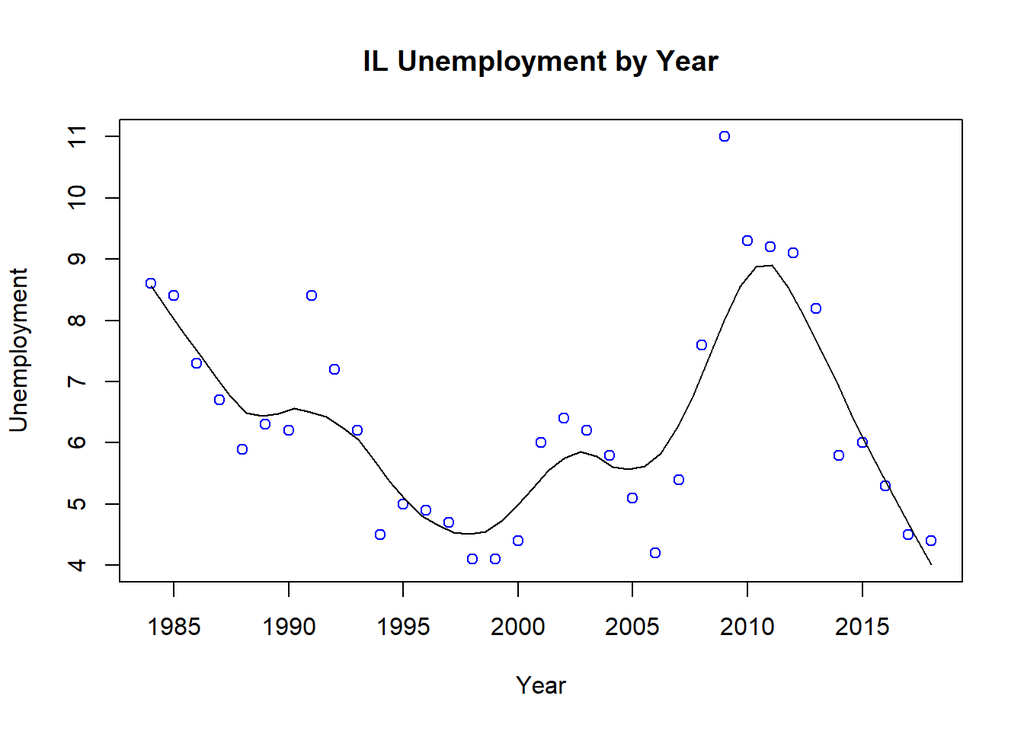

```r
scatter.smooth(IL_data$year, IL_data$value, main="IL Unemployment by Year", xlab = "Year", ylab = "Unemployment", col = "blue", span = 2/8)
```

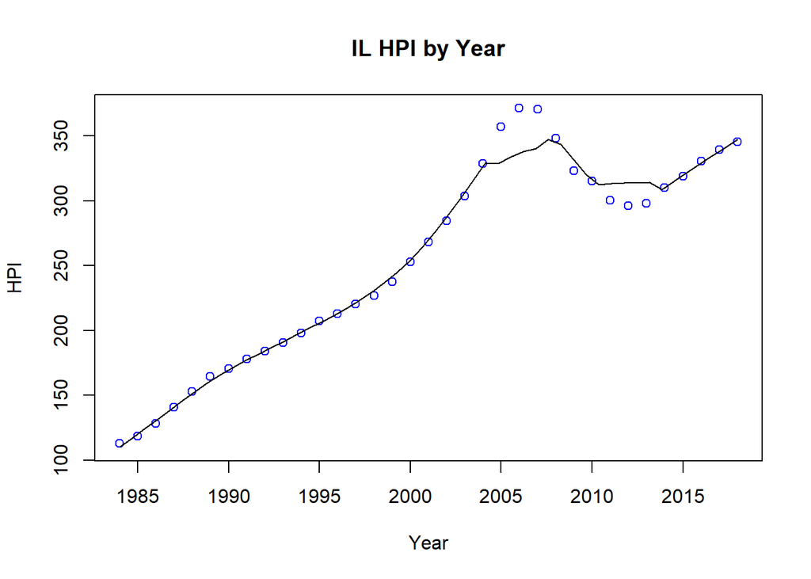

```r
scatter.smooth(IL_data$year, IL_data$HPI, main="IL HPI by Year", xlab = "Year", ylab = "HPI", col = "blue", span = 2/8)
```

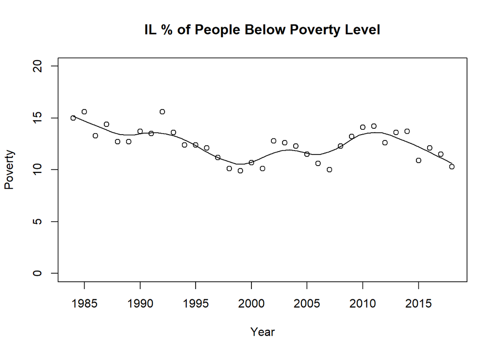

```r
scatter.smooth(x=IL_data$year, y=IL_data$poverty, main="IL % of People Below Poverty Level", xlab = "Year", ylab = "Poverty", ylim = c(0,20), span = 2/8)
```

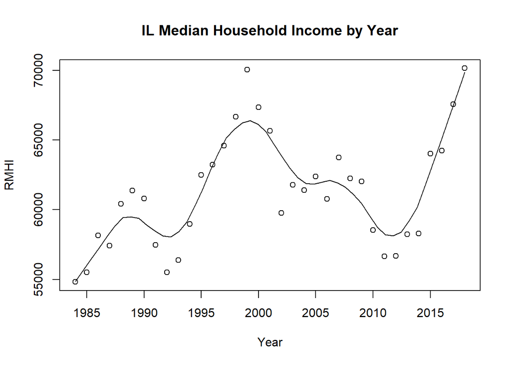

```r
IL_data$RMHI <- as.integer(IL_data$RMHI)
scatter.smooth(x=IL_data$year, y=IL_data$RMHI, main="IL Median Household Income by Year", xlab = "Year", ylab = "RMHI", span = 2/8 )
```

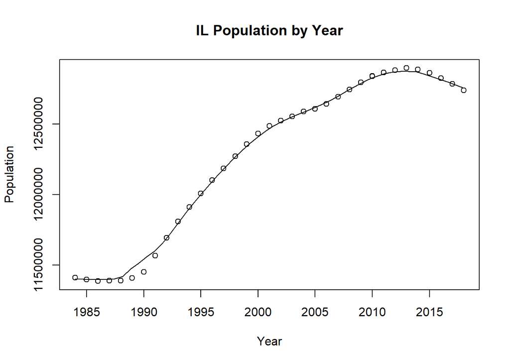

```r
IL_data$population <- as.integer(IL_data$population)
scatter.smooth(x=IL_data$year, y=IL_data$population, main="IL Population by Year", xlab = "Year", ylab = "Population", span = 2/8 )
```

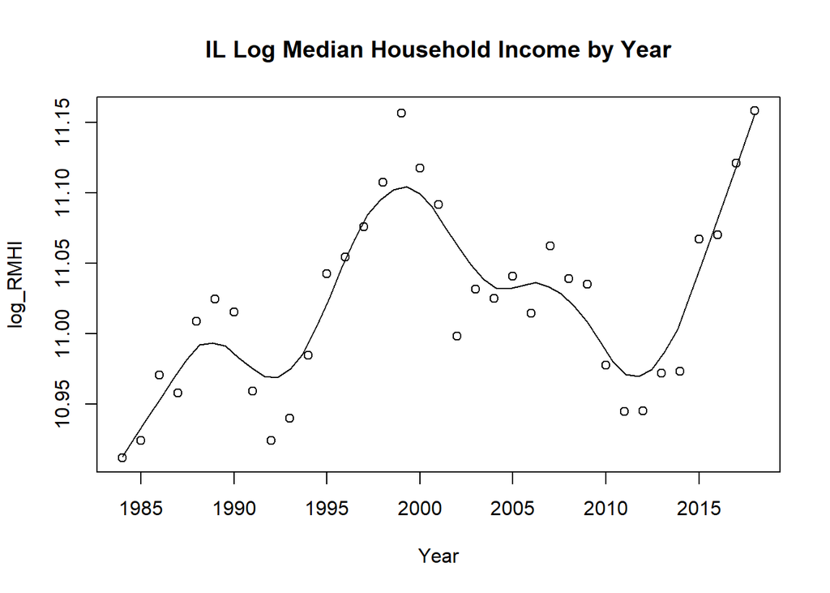

```r
#IL_data$log_RMHI <- as.integer(IL_data$log_RMHI)
scatter.smooth(x=IL_data$year, y=IL_data$log_RMHI, main="IL Log Median Household Income by Year", xlab = "Year", ylab = "log_RMHI", span = 2/8 )
```

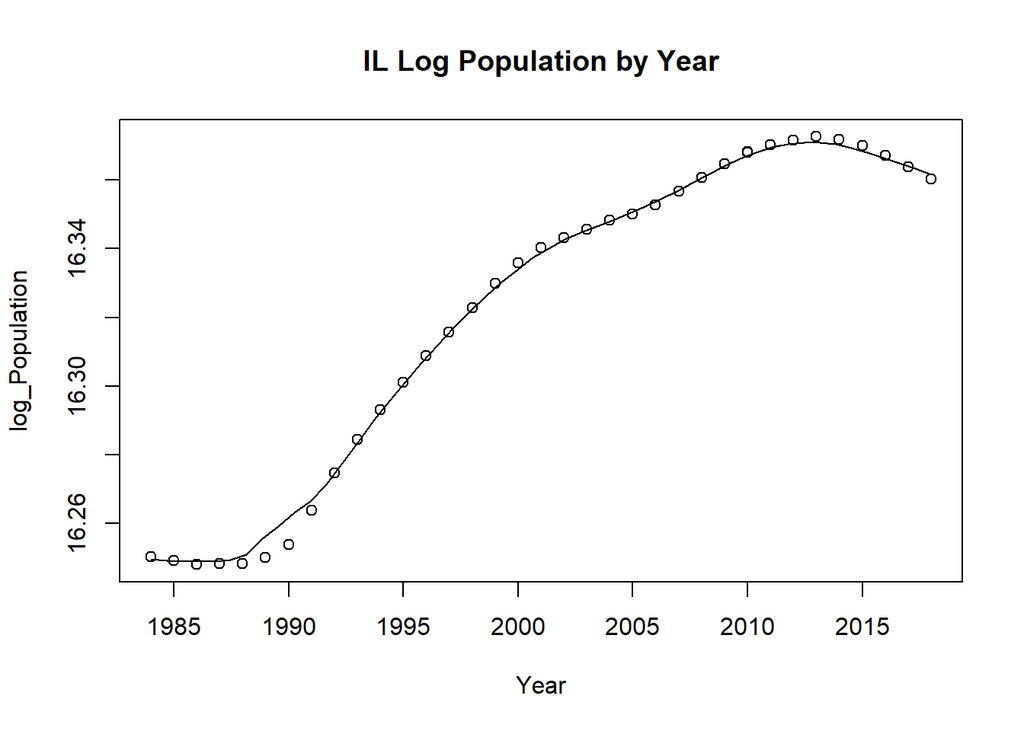

```r
#IL_data$log_pop <- as.integer(IL_data$log_pop)
scatter.smooth(x=IL_data$year, y=IL_data$log_pop, main="IL Log Population by Year", xlab = "Year", ylab = "log_Population", span = 2/8)
```

```r
cor(IL_data$RMHI, IL_data$value)
```

```
## [1] -0.6590005
```

```r
cor(IL_data$HPI, IL_data$value)
```

```
## [1] -0.08115831
```

```r
cor(IL_data$poverty, IL_data$value)
```

```
## [1] 0.6975789
```

```r
cor(IL_data$population, IL_data$value)
```

```
## [1] 0.02011968
```

```r
cor(IL_data$sp500, IL_data$value)
```

```
## [1] 0.03109792
```

```r
cor(IL_data$log_pop, IL_data$value)
```

```
## [1] 0.01123117
```

```r
cor(IL_data$log_RMHI, IL_data$value)
```

```
## [1] -0.6602776
```

```r
#run base correlations between categories and dependent variable
```

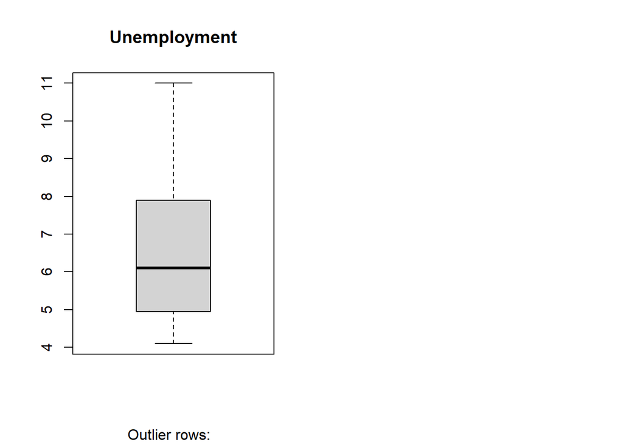

```r
par(mfrow=c(1, 2))  # divide graph area in 2 columns
boxplot(IL_data$value, main="Unemployment", sub=paste("Outlier rows: ", boxplot.stats(IL_data$value)$out))  # box plot for 'Unemployment'
```

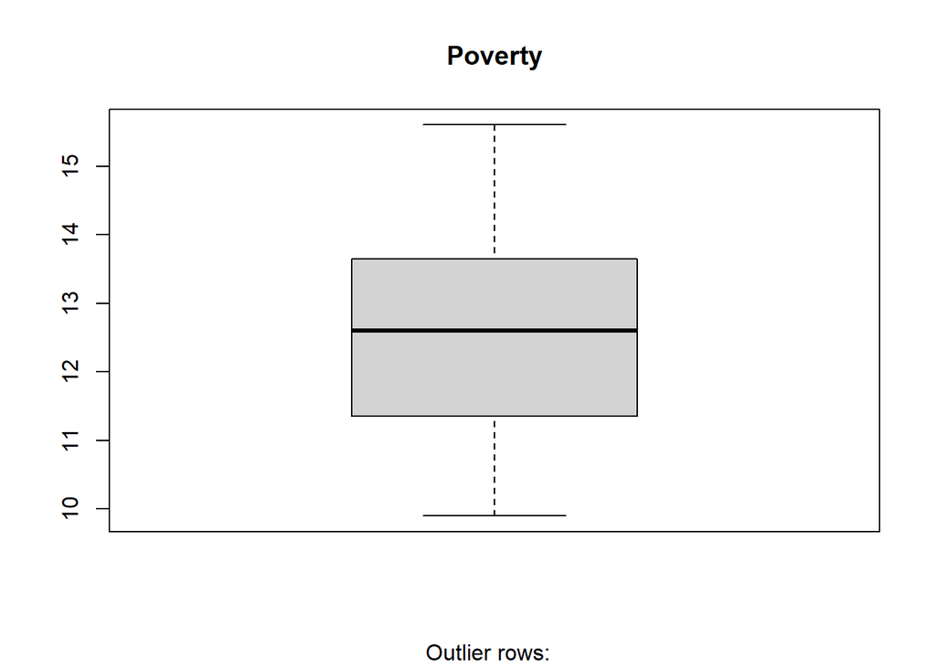

```r
boxplot(IL_data$poverty, main="Poverty", sub=paste("Outlier rows: ", boxplot.stats(IL_data$poverty)$out))  # box plot for 'Poverty'
```

```r
#create box plot for poverty level and unemployment level
```

```r
#run multiple linear model for data
IL_reg1 <- lm(value ~ poverty + RMHI + HPI + population + sp500, data = IL_data)
summary(IL_reg1)
```

```
##
## Call:
## lm(formula = value ~ poverty + RMHI + HPI + population + sp500,
##     data = IL_data)
##
## Residuals:
##     Min      1Q  Median      3Q     Max
## -2.5866 -0.7214 -0.0935  0.7777  3.6103
##
## Coefficients:
##               Estimate Std. Error t value Pr(>|t|)
## (Intercept) -1.676e+01  1.379e+01  -1.215   0.2337
## poverty      6.896e-01  2.776e-01   2.484   0.0188 *
## RMHI        -1.113e-04  1.033e-04  -1.077   0.2901
## HPI         -5.417e-03  8.027e-03  -0.675   0.5050
## population   1.851e-06  1.075e-06   1.723   0.0952 .
## sp500        2.284e-04  1.343e-02   0.017   0.9865
## ---
## Signif. codes:  0 '***' 0.001 '**' 0.01 '*' 0.05 '.' 0.1 ' ' 1
##
## Residual standard error: 1.217 on 30 degrees of freedom
## Multiple R-squared:  0.6143, Adjusted R-squared:  0.5501
## F-statistic: 9.558 on 5 and 30 DF,  p-value: 1.561e-05
```

```r
anova(IL_reg1)
```

```
## Analysis of Variance Table
##
## Response: value
##            Df Sum Sq Mean Sq F value    Pr(>F)
## poverty     1 56.050  56.050 37.8541 9.109e-07 ***
## RMHI        1  1.303   1.303  0.8798   0.35574
## HPI         1  8.899   8.899  6.0102   0.02026 *
## population  1  4.510   4.510  3.0461   0.09117 .
## sp500       1  0.000   0.000  0.0003   0.98654
## Residuals  30 44.420   1.481
## ---
## Signif. codes:  0 '***' 0.001 '**' 0.01 '*' 0.05 '.' 0.1 ' ' 1
```

```r
IL_reg2 <- lm(value ~ poverty + log_RMHI + HPI + log_pop + sp500, data = IL_data)
summary(IL_reg2)
```

```
##
## Call:
## lm(formula = value ~ poverty + log_RMHI + HPI + log_pop + sp500,
##     data = IL_data)
##
## Residuals:
##     Min      1Q  Median      3Q     Max
## -2.5575 -0.7142 -0.0868  0.7908  3.6217
##
## Coefficients:
##               Estimate Std. Error t value Pr(>|t|)
## (Intercept) -2.701e+02  2.170e+02  -1.245   0.2228
## poverty      6.973e-01  2.810e-01   2.481   0.0189 *
## log_RMHI    -6.889e+00  6.524e+00  -1.056   0.2994
## HPI         -4.554e-03  7.999e-03  -0.569   0.5733
## log_pop      2.113e+01  1.303e+01   1.621   0.1154
## sp500        5.088e-04  1.349e-02   0.038   0.9702
## ---
## Signif. codes:  0 '***' 0.001 '**' 0.01 '*' 0.05 '.' 0.1 ' ' 1
##
## Residual standard error: 1.222 on 30 degrees of freedom
## Multiple R-squared:  0.6109, Adjusted R-squared:  0.546
## F-statistic: 9.418 on 5 and 30 DF,  p-value: 1.773e-05
```

```r
anova(IL_reg2)
```

```
## Analysis of Variance Table
##
## Response: value
##           Df Sum Sq Mean Sq F value   Pr(>F)
## poverty    1 56.050  56.050 37.5138 9.84e-07 ***
## log_RMHI   1  1.249   1.249  0.8358  0.36789
## HPI        1  9.011   9.011  6.0310  0.02007 *
## log_pop    1  4.048   4.048  2.7091  0.11022
## sp500      1  0.002   0.002  0.0014  0.97017
## Residuals 30 44.823   1.494
## ---
## Signif. codes:  0 '***' 0.001 '**' 0.01 '*' 0.05 '.' 0.1 ' ' 1
```

```r
IL_linearModelSignificant <- lm(value ~ poverty + log_pop, data = IL_data)
summary(IL_linearModelSignificant)
```

```
##
## Call:
## lm(formula = value ~ poverty + log_pop, data = IL_data)
##
## Residuals:
##     Min      1Q  Median      3Q     Max
## -2.4468 -0.7344 -0.1555  0.7208  3.3382
##
## Coefficients:
##              Estimate Std. Error t value Pr(>|t|)
## (Intercept) -234.2508    78.4390  -2.986  0.00529 **
## poverty        0.9689     0.1397   6.937  6.3e-08 ***
## log_pop       14.0011     4.7604   2.941  0.00594 **
## ---
## Signif. codes:  0 '***' 0.001 '**' 0.01 '*' 0.05 '.' 0.1 ' ' 1
##
## Residual standard error: 1.192 on 33 degrees of freedom
## Multiple R-squared:  0.5932, Adjusted R-squared:  0.5686
## F-statistic: 24.06 on 2 and 33 DF,  p-value: 3.581e-07
```

```r
#test to show a scatterplot IL HPI data against year
```

```r
TX_data <- merged_final[ merged_final$state == "TX", ]
```

```r
#Descriptive statistics
stat.desc(TX_data)
```

```
##                      year period periodName       value state quarter annual
## nbr.val      3.600000e+01     NA         NA  36.0000000    NA      36     36
## nbr.null     0.000000e+00     NA         NA   0.0000000    NA       0      0
## nbr.na       0.000000e+00     NA         NA   0.0000000    NA       0      0
## min          1.984000e+03     NA         NA   3.5000000    NA       4      1
## max          2.018000e+03     NA         NA   8.5000000    NA       4      1
## range        3.400000e+01     NA         NA   5.0000000    NA       0      0
## sum          7.204500e+04     NA         NA 205.1000000    NA     144     36
## median       2.001500e+03     NA         NA   5.6500000    NA       4      1
## mean         2.001250e+03     NA         NA   5.6972222    NA       4      1
## SE.mean      1.701715e+00     NA         NA   0.2254268    NA       0      0
## CI.mean.0.95 3.454665e+00     NA         NA   0.4576407    NA       0      0
## var          1.042500e+02     NA         NA   1.8294206    NA       0      0
## std.dev      1.021029e+01     NA         NA   1.3525608    NA       0      0
## coef.var     5.101956e-03     NA         NA   0.2374071    NA       0      0
##                       HPI          MHI         RMHI      poverty   population
## nbr.val        36.0000000 3.600000e+01 3.600000e+01  36.00000000 3.600000e+01
## nbr.null        0.0000000 0.000000e+00 0.000000e+00   0.00000000 0.000000e+00
## nbr.na          0.0000000 0.000000e+00 0.000000e+00   0.00000000 0.000000e+00
## min           113.7700000 2.302400e+04 4.917700e+04  13.20000000 1.600709e+07
## max           334.9200000 6.009200e+04 6.155700e+04  19.10000000 2.870185e+07
## range         221.1500000 3.706800e+04 1.238000e+04   5.90000000 1.269476e+07
## sum          6687.8500000 1.424867e+06 1.969117e+06 592.50000000 7.822428e+08
## median        180.4800000 3.971000e+04 5.455400e+04  16.55000000 2.150497e+07
## mean          185.7736111 3.957964e+04 5.469769e+04  16.45833333 2.172897e+07
## SE.mean        10.2226857 1.881071e+03 5.124132e+02   0.22801333 6.691423e+05
## CI.mean.0.95   20.7531553 3.818777e+03 1.040254e+03   0.46289167 1.358431e+06
## var          3762.1189266 1.273834e+08 9.452421e+06   1.87164286 1.611905e+13
## std.dev        61.3361144 1.128642e+04 3.074479e+03   1.36807999 4.014854e+06
## coef.var        0.3301659 2.851573e-01 5.620857e-02   0.08312385 1.847697e-01
##                   sp500      log_pop     log_RMHI
## nbr.val       36.000000  36.00000000 3.600000e+01
## nbr.null       1.000000   0.00000000 0.000000e+00
## nbr.na         0.000000   0.00000000 0.000000e+00
## min          -38.490000  16.58854206 1.080318e+01
## max           34.110000  17.17247196 1.102772e+01
## range         72.600000   0.58392991 2.245375e-01
## sum          341.220000 607.58704791 3.926899e+02
## median        11.895000  16.88375765 1.090695e+01
## mean           9.478333  16.87741800 1.090805e+01
## SE.mean        2.652485   0.03100954 9.311408e-03
## CI.mean.0.95   5.384831   0.06295270 1.890316e-02
## var          253.284340   0.03461729 3.121284e-03
## std.dev       15.914909   0.18605721 5.586845e-02
## coef.var       1.679083   0.01102403 5.121761e-03
```

```r
#pairwise correlations
sapply(TX_data, class)
```

```
##        year      period  periodName       value       state     quarter
##   "numeric" "character" "character"   "numeric" "character"   "numeric"
##      annual         HPI         MHI        RMHI     poverty  population
##   "numeric"   "numeric"   "numeric"   "numeric"   "numeric"   "numeric"
##       sp500     log_pop    log_RMHI
##   "numeric"   "numeric"   "numeric"
```

```r
sapply(TX_data, is.factor)
```

```
##       year     period periodName      value      state    quarter     annual
##      FALSE      FALSE      FALSE      FALSE      FALSE      FALSE      FALSE
##        HPI        MHI       RMHI    poverty population      sp500    log_pop
##      FALSE      FALSE      FALSE      FALSE      FALSE      FALSE      FALSE
##   log_RMHI
##      FALSE
```

```r
cor(TX_data[sapply(TX_data, function(x) !is.character(x))])
```

```
##                  year       value quarter annual        HPI        MHI
## year        1.0000000 -0.40586425      NA     NA  0.9490575  0.9917495
## value      -0.4058642  1.00000000      NA     NA -0.4234252 -0.4429500
## quarter            NA          NA       1     NA         NA         NA
## annual             NA          NA      NA      1         NA         NA
## HPI         0.9490575 -0.42342522      NA     NA  1.0000000  0.9685900
## MHI         0.9917495 -0.44295000      NA     NA  0.9685900  1.0000000
## RMHI        0.7549419 -0.56630739      NA     NA  0.8086748  0.8217689
## poverty    -0.3839764  0.67190981      NA     NA -0.5300500 -0.4713178
## population  0.9951277 -0.38612661      NA     NA  0.9679242  0.9948080
## sp500      -0.1385293  0.09162901      NA     NA -0.1740205 -0.1513208
## log_pop     0.9983833 -0.39411107      NA     NA  0.9529186  0.9921431
## log_RMHI    0.7550869 -0.56262851      NA     NA  0.8048340  0.8205671
##                  RMHI    poverty population       sp500    log_pop   log_RMHI
## year        0.7549419 -0.3839764  0.9951277 -0.13852928  0.9983833  0.7550869
## value      -0.5663074  0.6719098 -0.3861266  0.09162901 -0.3941111 -0.5626285
## quarter            NA         NA         NA          NA         NA         NA
## annual             NA         NA         NA          NA         NA         NA
## HPI         0.8086748 -0.5300500  0.9679242 -0.17402046  0.9529186  0.8048340
## MHI         0.8217689 -0.4713178  0.9948080 -0.15132081  0.9921431  0.8205671
## RMHI        1.0000000 -0.7661225  0.7761129 -0.15576943  0.7672077  0.9993853
## poverty    -0.7661225  1.0000000 -0.4049827  0.21354689 -0.3874947 -0.7579950
## population  0.7761129 -0.4049827  1.0000000 -0.13537154  0.9971638  0.7760053
## sp500      -0.1557694  0.2135469 -0.1353715  1.00000000 -0.1408642 -0.1571481
## log_pop     0.7672077 -0.3874947  0.9971638 -0.14086421  1.0000000  0.7683718
## log_RMHI    0.9993853 -0.7579950  0.7760053 -0.15714808  0.7683718  1.0000000
```

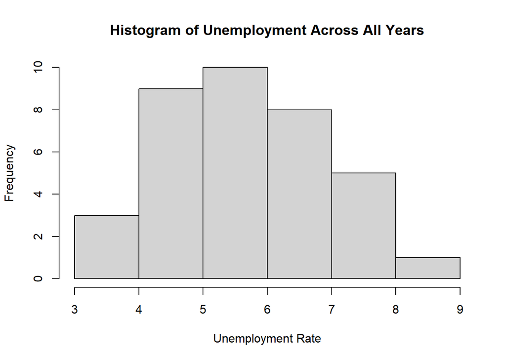

```r
hist(TX_data$value,
     main="Histogram of Unemployment Across All Years",
     xlim=c(3,9),
     xlab="Unemployment Rate",
     breaks = 5)
```

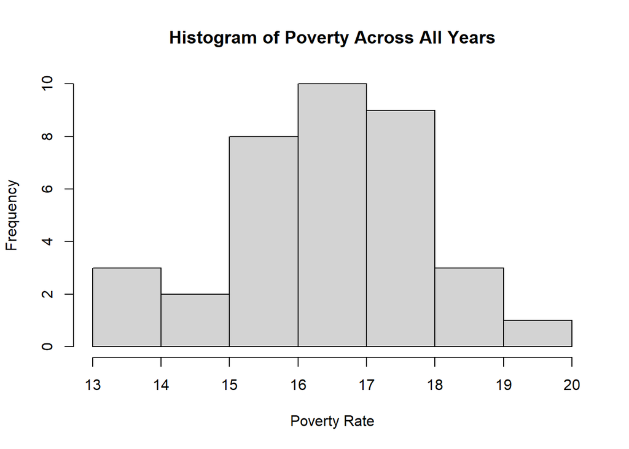

```r
hist(TX_data$poverty,
     main="Histogram of Poverty Across All Years",
     xlim=c(13,20),
     xlab="Poverty Rate",
     breaks = 5)
```

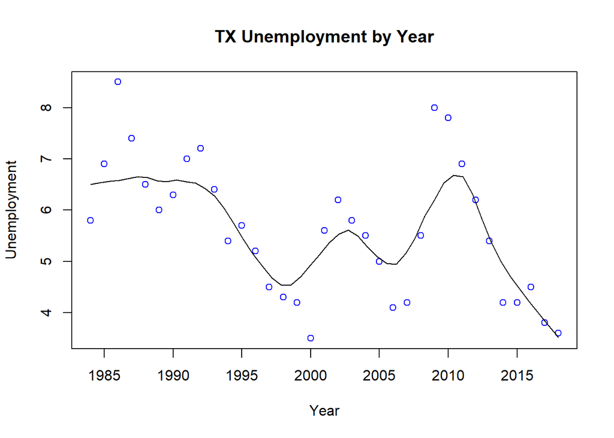

```r
scatter.smooth(TX_data$year, TX_data$value, main="TX Unemployment by Year", xlab = "Year", ylab = "Unemployment", col = "blue", span = 2/8)
```

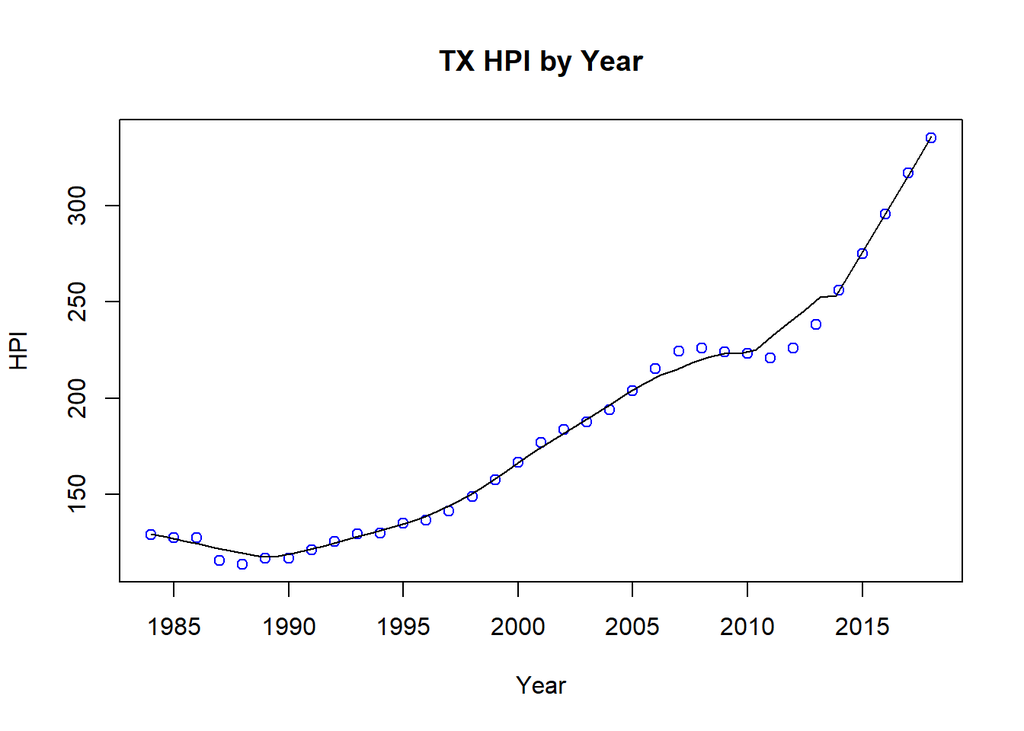

```r
scatter.smooth(TX_data$year, TX_data$HPI, main="TX HPI by Year", xlab = "Year", ylab = "HPI", col = "blue", span = 2/8)
```

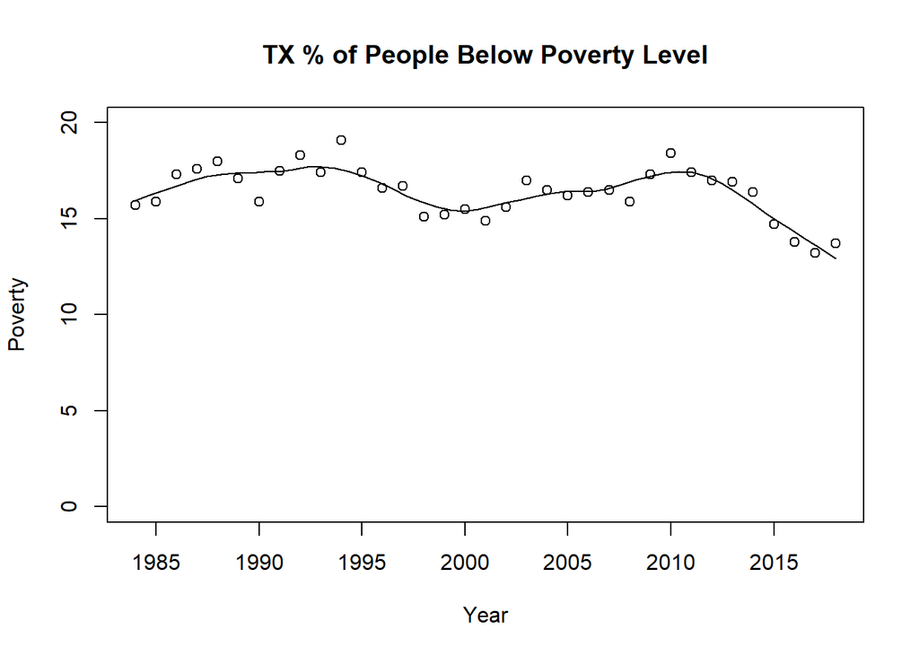

```r
scatter.smooth(x=TX_data$year, y=TX_data$poverty, main="TX % of People Below Poverty Level", xlab = "Year", ylab = "Poverty", ylim = c(0,20), span = 2/8)
```

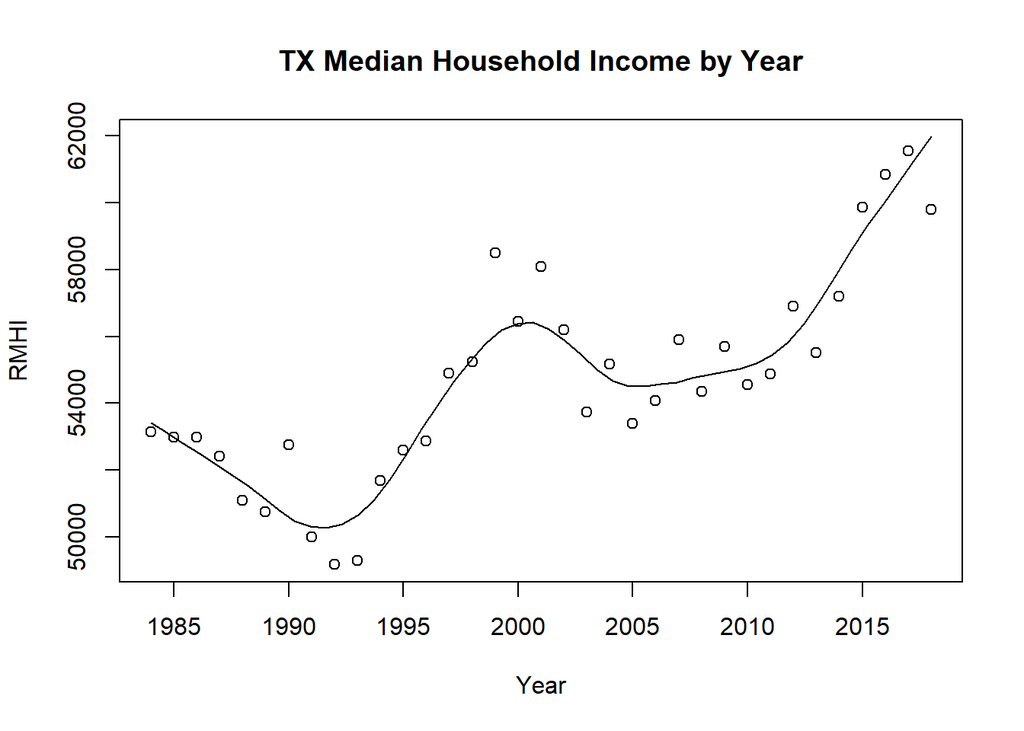

```r
TX_data$RMHI <- as.integer(TX_data$RMHI)
scatter.smooth(x=TX_data$year, y=TX_data$RMHI, main="TX Median Household Income by Year", xlab = "Year", ylab = "RMHI", span = 2/8 )
```

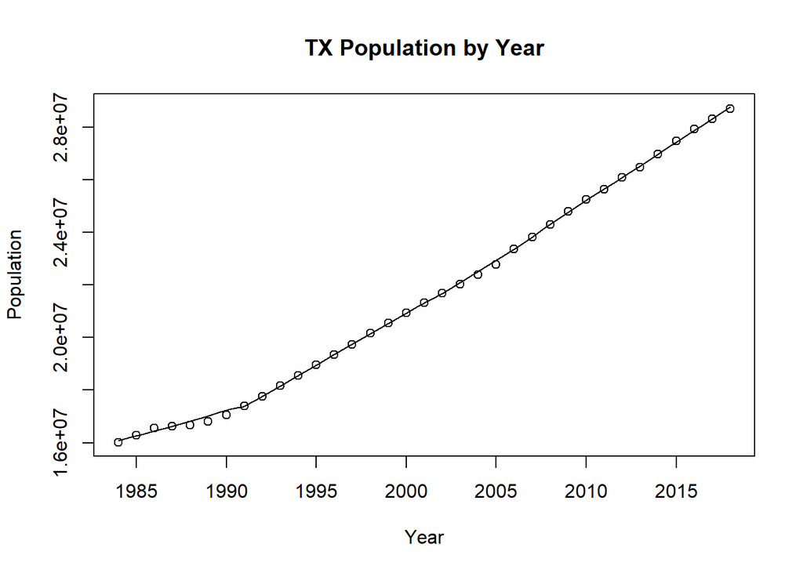

```r
TX_data$population <- as.integer(TX_data$population)
scatter.smooth(x=TX_data$year, y=TX_data$population, main="TX Population by Year", xlab = "Year", ylab = "Population", span = 2/8 )
```

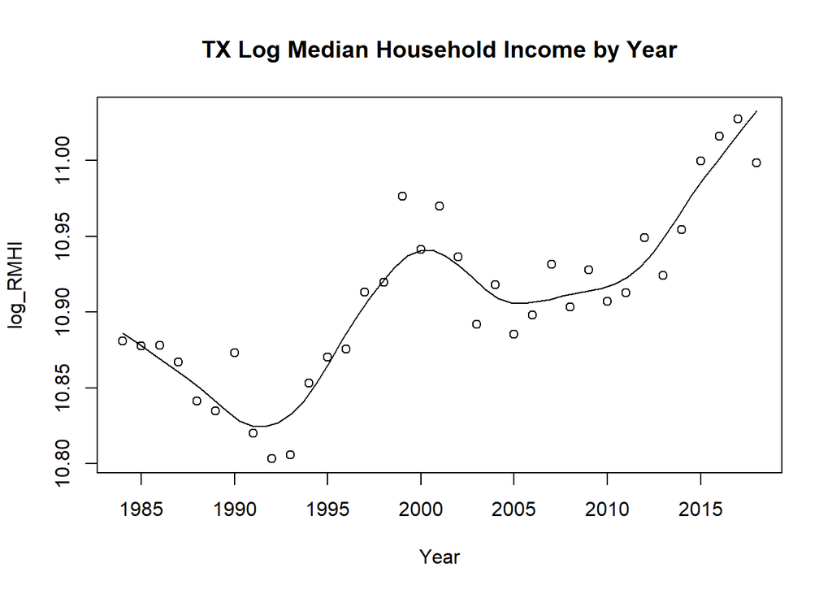

```r
#TX_data$log_RMHI <- as.integer(TX_data$log_RMHI)
scatter.smooth(x=TX_data$year, y=TX_data$log_RMHI, main="TX Log Median Household Income by Year", xlab = "Year", ylab = "log_RMHI", span = 2/8 )
```

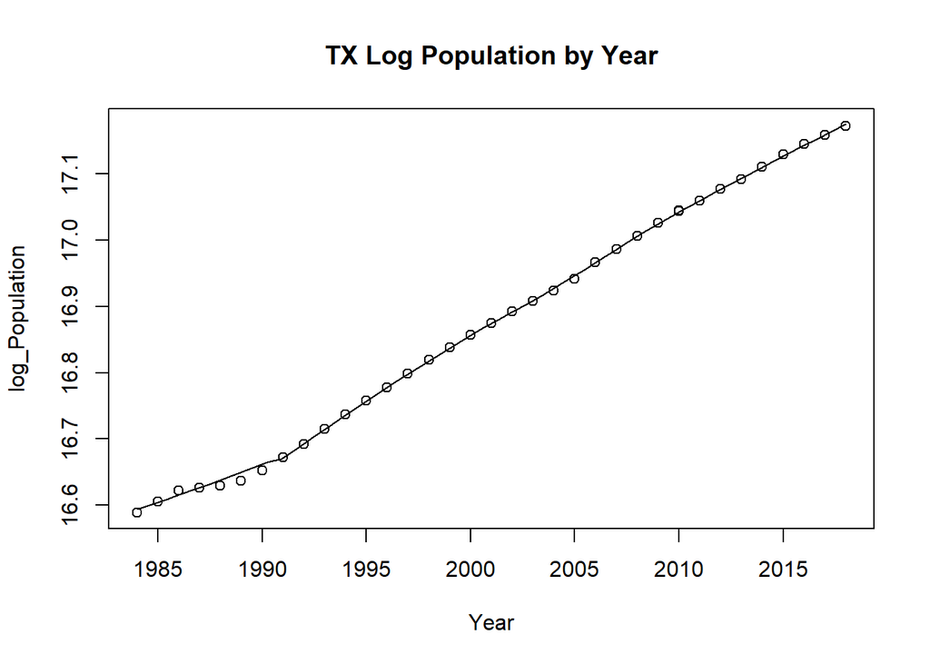

```r
#TX_data$log_pop <- as.integer(TX_data$log_pop)
scatter.smooth(x=TX_data$year, y=TX_data$log_pop, main="TX Log Population by Year", xlab = "Year", ylab = "log_Population", span = 2/8)
```

```r
cor(TX_data$RMHI, TX_data$value)
```

```
## [1] -0.5663074
```

```r
cor(TX_data$HPI, TX_data$value)
```

```
## [1] -0.4234252
```

```r
cor(TX_data$poverty, TX_data$value)
```

```
## [1] 0.6719098
```

```r
cor(TX_data$population, TX_data$value)
```

```
## [1] -0.3861266
```

```r
cor(TX_data$sp500, TX_data$value)
```

```
## [1] 0.09162901
```

```r
cor(TX_data$log_pop, TX_data$value)
```

```
## [1] -0.3941111
```

```r
cor(TX_data$log_RMHI, TX_data$value)
```

```
## [1] -0.5626285
```

```r
#run base correlations between categories and dependent variable
```

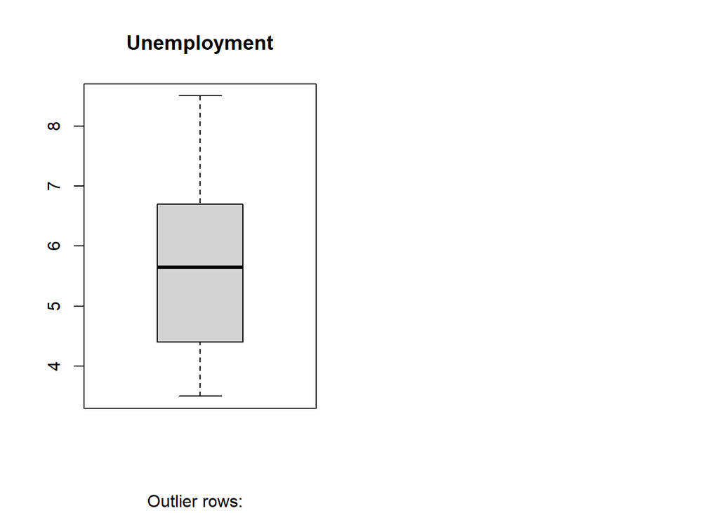

```r
par(mfrow=c(1, 2))  # divide graph area in 2 columns
boxplot(TX_data$value, main="Unemployment", sub=paste("Outlier rows: ", boxplot.stats(TX_data$value)$out))  # box plot for 'Unemployment'
```

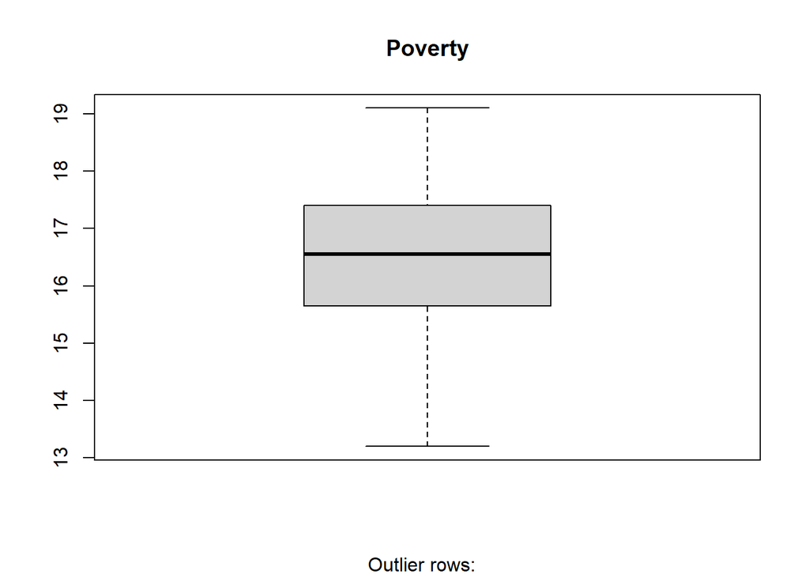

```r
boxplot(TX_data$poverty, main="Poverty", sub=paste("Outlier rows: ", boxplot.stats(TX_data$poverty)$out))  # box plot for 'Poverty'
```

```r
#create box plot for poverty level and unemployment level
```

```r
#run multiple linear model for data
TX_reg1 <- lm(value ~ poverty + RMHI + HPI + population + sp500, data = TX_data)
summary(TX_reg1)
```

```
##
## Call:
## lm(formula = value ~ poverty + RMHI + HPI + population + sp500,
##     data = TX_data)
##
## Residuals:
##      Min       1Q   Median       3Q      Max
## -2.42022 -0.50730  0.00617  0.69676  1.87937
##
## Coefficients:
##               Estimate Std. Error t value Pr(>|t|)
## (Intercept) -9.230e+00  1.015e+01  -0.909  0.37042
## poverty      8.773e-01  2.687e-01   3.265  0.00274 **
## RMHI         8.587e-05  1.481e-04   0.580  0.56640
## HPI          2.074e-02  1.448e-02   1.433  0.16225
## population  -3.691e-07  2.264e-07  -1.631  0.11340
## sp500       -4.429e-03  1.126e-02  -0.393  0.69675
## ---
## Signif. codes:  0 '***' 0.001 '**' 0.01 '*' 0.05 '.' 0.1 ' ' 1
##
## Residual standard error: 1.027 on 30 degrees of freedom
## Multiple R-squared:  0.5057, Adjusted R-squared:  0.4234
## F-statistic:  6.14 on 5 and 30 DF,  p-value: 0.0004974
```

```r
anova(TX_reg1)
```

```
## Analysis of Variance Table
##
## Response: value
##            Df Sum Sq Mean Sq F value  Pr(>F)
## poverty     1 28.907 28.9070 27.4029 1.2e-05 ***
## RMHI        1  0.412  0.4118  0.3904  0.5368
## HPI         1  0.057  0.0569  0.0540  0.8179
## population  1  2.844  2.8439  2.6959  0.1111
## sp500       1  0.163  0.1633  0.1548  0.6968
## Residuals  30 31.647  1.0549
## ---
## Signif. codes:  0 '***' 0.001 '**' 0.01 '*' 0.05 '.' 0.1 ' ' 1
```

```r
TX_reg2 <- lm(value ~ poverty + log_RMHI + HPI + log_pop + sp500, data = TX_data)
summary(TX_reg2)
```

```
##
## Call:
## lm(formula = value ~ poverty + log_RMHI + HPI + log_pop + sp500,
##     data = TX_data)
##
## Residuals:
##      Min       1Q   Median       3Q      Max
## -2.44168 -0.44509  0.03532  0.65192  1.92015
##
## Coefficients:
##              Estimate Std. Error t value Pr(>|t|)
## (Intercept) 56.107242  79.166345   0.709  0.48397
## poverty      0.897958   0.249964   3.592  0.00115 **
## log_RMHI     5.467371   7.723899   0.708  0.48450
## HPI          0.018999   0.011315   1.679  0.10353
## log_pop     -7.602177   3.827211  -1.986  0.05620 .
## sp500       -0.005457   0.011027  -0.495  0.62428
## ---
## Signif. codes:  0 '***' 0.001 '**' 0.01 '*' 0.05 '.' 0.1 ' ' 1
##
## Residual standard error: 1.007 on 30 degrees of freedom
## Multiple R-squared:  0.5247, Adjusted R-squared:  0.4454
## F-statistic: 6.622 on 5 and 30 DF,  p-value: 0.0002909
```

```r
anova(TX_reg2)
```

```
## Analysis of Variance Table
##
## Response: value
##           Df  Sum Sq Mean Sq F value    Pr(>F)
## poverty    1 28.9070 28.9070 28.4926 8.973e-06 ***
## log_RMHI   1  0.4279  0.4279  0.4218   0.52098
## HPI        1  0.0533  0.0533  0.0526   0.82019
## log_pop    1  3.9565  3.9565  3.8998   0.05756 .
## sp500      1  0.2485  0.2485  0.2449   0.62428
## Residuals 30 30.4364  1.0145
## ---
## Signif. codes:  0 '***' 0.001 '**' 0.01 '*' 0.05 '.' 0.1 ' ' 1
```

```r
TX_linearModelSignificant <- lm(value ~ poverty + log_pop, data = TX_data)
summary(TX_linearModelSignificant)
```

```
##
## Call:
## lm(formula = value ~ poverty + log_pop, data = TX_data)
##
## Residuals:
##      Min       1Q   Median       3Q      Max
## -2.05373 -0.65686 -0.07282  0.71777  2.00284
##
## Coefficients:
##             Estimate Std. Error t value Pr(>|t|)
## (Intercept)  15.0658    17.8113   0.846    0.404
## poverty       0.6040     0.1356   4.455 9.11e-05 ***
## log_pop      -1.1441     0.9970  -1.148    0.259
## ---
## Signif. codes:  0 '***' 0.001 '**' 0.01 '*' 0.05 '.' 0.1 ' ' 1
##
## Residual standard error: 1.012 on 33 degrees of freedom
## Multiple R-squared:  0.4725, Adjusted R-squared:  0.4405
## F-statistic: 14.78 on 2 and 33 DF,  p-value: 2.609e-05
```

```r
#test to show a scatterplot TX HPI data against year
```

```r
MO_data <- merged_final[ merged_final$state == "MO", ]
```

```r
#Descriptive statistics
stat.desc(MO_data)
```

```
##                      year period periodName       value state quarter annual
## nbr.val      3.600000e+01     NA         NA  36.0000000    NA      36     36
## nbr.null     0.000000e+00     NA         NA   0.0000000    NA       0      0
## nbr.na       0.000000e+00     NA         NA   0.0000000    NA       0      0
## min          1.984000e+03     NA         NA   2.8000000    NA       4      1
## max          2.018000e+03     NA         NA   9.4000000    NA       4      1
## range        3.400000e+01     NA         NA   6.6000000    NA       0      0
## sum          7.204500e+04     NA         NA 194.5000000    NA     144     36
## median       2.001500e+03     NA         NA   5.2000000    NA       4      1
## mean         2.001250e+03     NA         NA   5.4027778    NA       4      1
## SE.mean      1.701715e+00     NA         NA   0.2712840    NA       0      0
## CI.mean.0.95 3.454665e+00     NA         NA   0.5507358    NA       0      0
## var          1.042500e+02     NA         NA   2.6494206    NA       0      0
## std.dev      1.021029e+01     NA         NA   1.6277041    NA       0      0
## coef.var     5.101956e-03     NA         NA   0.3012717    NA       0      0
##                       HPI          MHI         RMHI     poverty   population
## nbr.val        36.0000000 3.600000e+01 3.600000e+01  36.0000000 3.600000e+01
## nbr.null        0.0000000 0.000000e+00 0.000000e+00   0.0000000 0.000000e+00
## nbr.na          0.0000000 0.000000e+00 0.000000e+00   0.0000000 0.000000e+00
## min           118.9400000 2.077500e+04 4.795600e+04   9.2000000 4.975278e+06
## max           334.6000000 6.172600e+04 6.594300e+04  17.5000000 6.126452e+06
## range         215.6600000 4.095100e+04 1.798700e+04   8.3000000 1.151174e+06
## sum          8063.2700000 1.433078e+06 1.978707e+06 461.1000000 2.020229e+08
## median        235.4550000 4.245650e+04 5.509500e+04  12.7500000 5.657984e+06
## mean          223.9797222 3.980772e+04 5.496408e+04  12.8083333 5.611748e+06
## SE.mean        10.9568132 1.909017e+03 8.226538e+02   0.3788113 6.452331e+04
## CI.mean.0.95   22.2435133 3.875511e+03 1.670076e+03   0.7690279 1.309893e+05
## var          4321.8631913 1.311965e+08 2.436334e+07   5.1659286 1.498773e+11
## std.dev        65.7408791 1.145410e+04 4.935923e+03   2.2728679 3.871399e+05
## coef.var        0.2935126 2.877357e-01 8.980270e-02   0.1774523 6.898739e-02
##                   sp500      log_pop     log_RMHI
## nbr.val       36.000000 3.600000e+01 3.600000e+01
## nbr.null       1.000000 0.000000e+00 0.000000e+00
## nbr.na         0.000000 0.000000e+00 0.000000e+00
## min          -38.490000 1.541999e+01 1.077804e+01
## max           34.110000 1.562813e+01 1.109655e+01
## range         72.600000 2.081345e-01 3.185068e-01
## sum          341.220000 5.593689e+02 3.927797e+02
## median        11.895000 1.554857e+01 1.091680e+01
## mean           9.478333 1.553802e+01 1.091055e+01
## SE.mean        2.652485 1.162907e-02 1.488114e-02
## CI.mean.0.95   5.384831 2.360826e-02 3.021032e-02
## var          253.284340 4.868468e-03 7.972142e-03
## std.dev       15.914909 6.977440e-02 8.928685e-02
## coef.var       1.679083 4.490558e-03 8.183536e-03
```

```r
#pairwise correlations
sapply(MO_data, class)
```

```
##        year      period  periodName       value       state     quarter
##   "numeric" "character" "character"   "numeric" "character"   "numeric"
##      annual         HPI         MHI        RMHI     poverty  population
##   "numeric"   "numeric"   "numeric"   "numeric"   "numeric"   "numeric"
##       sp500     log_pop    log_RMHI
##   "numeric"   "numeric"   "numeric"
```

```r
sapply(MO_data, is.factor)
```

```
##       year     period periodName      value      state    quarter     annual
##      FALSE      FALSE      FALSE      FALSE      FALSE      FALSE      FALSE
##        HPI        MHI       RMHI    poverty population      sp500    log_pop
##      FALSE      FALSE      FALSE      FALSE      FALSE      FALSE      FALSE
##   log_RMHI
##      FALSE
```

```r
cor(MO_data[sapply(MO_data, function(x) !is.character(x))])
```

```
##                   year       value quarter annual         HPI        MHI
## year        1.00000000  0.03932598      NA     NA  0.96247567  0.9726852
## value       0.03932598  1.00000000      NA     NA  0.05064891 -0.1003401
## quarter             NA          NA       1     NA          NA         NA
## annual              NA          NA      NA      1          NA         NA
## HPI         0.96247567  0.05064891      NA     NA  1.00000000  0.9414550
## MHI         0.97268516 -0.10034014      NA     NA  0.94145501  1.0000000
## RMHI        0.53539838 -0.48320728      NA     NA  0.54023310  0.7065757
## poverty    -0.08627458  0.60392697      NA     NA -0.14229157 -0.2678414
## population  0.99237309  0.08687034      NA     NA  0.97055778  0.9645918
## sp500      -0.13852928 -0.09530716      NA     NA -0.21070547 -0.1582891
## log_pop     0.99028187  0.08057646      NA     NA  0.97005431  0.9644376
## log_RMHI    0.55197300 -0.47258868      NA     NA  0.55920640  0.7191751
##                   RMHI     poverty  population       sp500     log_pop
## year        0.53539838 -0.08627458  0.99237309 -0.13852928  0.99028187
## value      -0.48320728  0.60392697  0.08687034 -0.09530716  0.08057646
## quarter             NA          NA          NA          NA          NA
## annual              NA          NA          NA          NA          NA
## HPI         0.54023310 -0.14229157  0.97055778 -0.21070547  0.97005431
## MHI         0.70657575 -0.26784136  0.96459181 -0.15828913  0.96443763
## RMHI        1.00000000 -0.74240102  0.54710579 -0.09670204  0.55761992
## poverty    -0.74240102  1.00000000 -0.09707523  0.07310805 -0.10826802
## population  0.54710579 -0.09707523  1.00000000 -0.14829752  0.99966603
## sp500      -0.09670204  0.07310805 -0.14829752  1.00000000 -0.14884087
## log_pop     0.55761992 -0.10826802  0.99966603 -0.14884087  1.00000000
## log_RMHI    0.99905007 -0.74145337  0.56470044 -0.09169904  0.57538155
##               log_RMHI
## year        0.55197300
## value      -0.47258868
## quarter             NA
## annual              NA
## HPI         0.55920640
## MHI         0.71917505
## RMHI        0.99905007
## poverty    -0.74145337
## population  0.56470044
## sp500      -0.09169904
## log_pop     0.57538155
## log_RMHI    1.00000000
```